# TEST R Notebook of QALL401

123456 H.S.

2023-01-28

> Revised on January 25

# About

I try to investigate the education of the world using the data from UN, WIR and WDI.

# Set up

```r
library(tidyverse)
library(WDI)
library(readxl)
```

# Importing Data

## URLs

WIR2022 Executive Summary

```r
wir2022 <- "https://wir2022.wid.world/www-site/uploads/2022/03/WIR2022TablesFigures-Summary.xlsx"
```

UN Education data at https://data.un.org/.

```r
url <- "https://data.un.org/_Docs/SYB/CSV/SYB65_309_202209_Education.csv"
```

By `readr::read_csv`, you can directly download and read the data.

Since the first row is not the column names, an option `skip = 1` is applied.

```r
un_ed <- read_csv(url, skip = 1)
```

```r
un_ed
```

| Region/Country/Area | ...2 | Year | Series | Value | Footnotes | Source |
| --- | --- | --- | --- | --- | --- | --- |
| 1 | Total, all countries or areas | 2005 | Students enrolled in primary education (thousands) | 679014.0 | NA | United Nations Educational, Scientific and Cultural Organization (UNESCO), Montreal, the UNESCO Institute for Statistics (UIS) statistics database, last accessed May 2022. |
| 1 | Total, all countries or areas | 2005 | Gross enrollment ratio - Primary (male) | 104.5 | NA | United Nations Educational, Scientific and Cultural Organization (UNESCO), Montreal, the UNESCO Institute for Statistics (UIS) statistics database, last accessed May 2022. |
| 1 | Total, all countries or areas | 2005 | Gross enrollment ratio - Primary (female) | 99.7 | NA | United Nations Educational, Scientific and Cultural Organization (UNESCO), Montreal, the UNESCO Institute for Statistics (UIS) statistics database, last accessed May 2022. |
| 1 | Total, all countries or areas | 2005 | Students enrolled in secondary education (thousands) | 509277.0 | NA | United Nations Educational, Scientific and Cultural Organization (UNESCO), Montreal, the UNESCO Institute for Statistics (UIS) statistics database, last accessed May 2022. |
| 1 | Total, all countries or areas | 2005 | Gross enrollment ratio - Secondary (male) | 65.8 | NA | United Nations Educational, Scientific and Cultural Organization (UNESCO), Montreal, the UNESCO Institute for Statistics (UIS) statistics database, last accessed May 2022. |
| 1 | Total, all countries or areas | 2005 | Gross enrollment ratio - Secondary (female) | 62.3 | NA | United Nations Educational, Scientific and Cultural Organization (UNESCO), Montreal, the UNESCO Institute for Statistics (UIS) statistics database, last accessed May 2022. |
| 1 | Total, all countries or areas | 2005 | Students enrolled in upper secondary education (thousands) | 199756.0 | NA | United Nations Educational, Scientific and Cultural Organization (UNESCO), Montreal, the UNESCO Institute for Statistics (UIS) statistics database, last accessed May 2022. |
| 1 | Total, all countries or areas | 2005 | Gross enrollment ratio - Upper secondary level (male) | 51.2 | NA | United Nations Educational, Scientific and Cultural Organization (UNESCO), Montreal, the UNESCO Institute for Statistics (UIS) statistics database, last accessed May 2022. |
| 1 | Total, all countries or areas | 2005 | Gross enrollment ratio - Upper secondary level (female) | 48.3 | NA | United Nations Educational, Scientific and Cultural Organization (UNESCO), Montreal, the UNESCO Institute for Statistics (UIS) statistics database, last accessed May 2022. |
| 1 | Total, all countries or areas | 2010 | Students enrolled in primary education (thousands) | 697382.0 | NA | United Nations Educational, Scientific and Cultural Organization (UNESCO), Montreal, the UNESCO Institute for Statistics (UIS) statistics database, last accessed May 2022. |

[output cut: 990 more lines]

As for an Excel data, you need to download first. It will be written in the `data` folder. *You need to add ./ before data.*

```r
download.file(url = wir2022, destfile = "./data/wir2022.xlsx", mode = "wb")
```

The package `readxl` is installed with `tidyverse` package but not loaded with `tidyverse`. Add `library(readxl)` if it is not in Setup.

```r
wir_df1 <- read_excel("./data/wir2022.xlsx", sheet = 1)
```

```r
wir_df1
```

| Figures/Table | Title |
| --- | --- |
| F1 | Global income and wealth inequality, 2021 |
| F2 | The poorest half lags behind: Bottom 50%, middle 40% and top 10% income shares across the world in 2021 |
| F3 | Top 10/Bottom 50 income gaps across the world, 2021 |
| F4 | The extreme concentration of capital: wealth inequality across the world, 2021 |
| F5 | Global income inequality: T10/B50 ratio, 1820-2020 |
| F6 | Global income inequality: Between vs. Within country inequality (Theil index), 1820-2020 |
| F7 | Global income inequality, 1820-2020 |
| F8 | The rise of private versus the decline of public wealth in rich countries, 1970-2020 |
| F9 | Average annual wealth growth rate, 1995-2021 |
| F10 | The share of wealth owned by the global 0.1% and billionaires, 2021 |

[output cut: 6 more lines]

By the following `excel_sheets` you can get a list of sheets. There are 32 sheets.

```r
excel_sheets("./data/wir2022.xlsx")
```

```
 [1] "Index"     "F1"        "F2"        "F3"        "F4"        "F5."
 [7] "F6"        "F7"        "F8"        "F9"        "F10"       "F11"
[13] "F12"       "F13"       "F14"       "F15"       "T1"        "data-F1"
[19] "data-F2"   "data-F3"   "data-F4"   "data-F5"   "data-F6"   "data-F7"
[25] "data-F8"   "data-F9"   "data-F10"  "data-F11"  "data-F12"  "data-F13."
[31] "data-F14." "data-F15"
```

```r
df_F1 <- read_excel("./data/wir2022.xlsx", sheet = "data-F1"); df_F1
```

| ...1 | Bottom 50% | Middle 40% | Top 10% | Top 1% |
| --- | --- | --- | --- | --- |
| Income | 0.0840 | 0.3942 | 0.5217 | 0.1925 |
| Wealth | 0.0199 | 0.2245 | 0.7556 | 0.3779 |

## WDI Package

It is convenient to have `WDIcache().`

```r
wdi_cache <- WDIcache()
```

```r
wdi_cache$series
```

| indicator | name | description | sourceDatabase | sourceOrganization |
| --- | --- | --- | --- | --- |
| 1.0.HCount.1.90usd | Poverty Headcount ($1.90 a day) | The poverty headcount index measures the proportion of the population with daily per capita income (in 2011 PPP) below the poverty line. | LAC Equity Lab | LAC Equity Lab tabulations of SEDLAC (CEDLAS and the World Bank). |
| 1.0.HCount.2.5usd | Poverty Headcount ($2.50 a day) | The poverty headcount index measures the proportion of the population with daily per capita income (in 2005 PPP) below the poverty line. | LAC Equity Lab | LAC Equity Lab tabulations of SEDLAC (CEDLAS and the World Bank). |
| 1.0.HCount.Mid10to50 | Middle Class ($10-50 a day) Headcount | The poverty headcount index measures the proportion of the population with daily per capita income (in 2005 PPP) below the poverty line. | LAC Equity Lab | LAC Equity Lab tabulations of SEDLAC (CEDLAS and the World Bank). |
| 1.0.HCount.Ofcl | Official Moderate Poverty Rate-National | The poverty headcount index measures the proportion of the population with daily per capita income below the official poverty line developed by each country. | LAC Equity Lab | LAC Equity Lab tabulations of data from National Statistical Offices. |
| 1.0.HCount.Poor4uds | Poverty Headcount ($4 a day) | The poverty headcount index measures the proportion of the population with daily per capita income (in 2005 PPP) below the poverty line. | LAC Equity Lab | LAC Equity Lab tabulations of SEDLAC (CEDLAS and the World Bank). |
| 1.0.HCount.Vul4to10 | Vulnerable ($4-10 a day) Headcount | The poverty headcount index measures the proportion of the population with daily per capita income (in 2005 PPP) below the poverty line. | LAC Equity Lab | LAC Equity Lab tabulations of SEDLAC (CEDLAS and the World Bank). |
| 1.0.PGap.1.90usd | Poverty Gap ($1.90 a day) | The poverty gap captures the mean aggregate income or consumption shortfall relative to the poverty line across the entire population. It measures the total resources needed to bring all the poor to t… | LAC Equity Lab | LAC Equity Lab tabulations of SEDLAC (CEDLAS and the World Bank). |
| 1.0.PGap.2.5usd | Poverty Gap ($2.50 a day) | The poverty gap captures the mean aggregate income or consumption shortfall relative to the poverty line across the entire population. It measures the total resources needed to bring all the poor to t… | LAC Equity Lab | LAC Equity Lab tabulations of SEDLAC (CEDLAS and the World Bank). |
| 1.0.PGap.Poor4uds | Poverty Gap ($4 a day) | The poverty gap captures the mean aggregate income or consumption shortfall relative to the poverty line across the entire population. It measures the total resources needed to bring all the poor to t… | LAC Equity Lab | LAC Equity Lab tabulations of SEDLAC (CEDLAS and the World Bank). |
| 1.0.PSev.1.90usd | Poverty Severity ($1.90 a day) | The poverty severity index combines information on both poverty and inequality among the poor by averaging the squares of the poverty gaps relative the poverty line | LAC Equity Lab | LAC Equity Lab tabulations of SEDLAC (CEDLAS and the World Bank). |

[output cut: 990 more lines]

```r
wdi_cache$country
```

| iso3c | iso2c | country | region | capital | longitude | latitude | income | lending |
| --- | --- | --- | --- | --- | --- | --- | --- | --- |
| ABW | AW | Aruba | Latin America & Caribbean | Oranjestad | -70.0167 | 12.5167 | High income | Not classified |
| AFE | ZH | Africa Eastern and Southern | Aggregates |  |  |  | Aggregates | Aggregates |
| AFG | AF | Afghanistan | South Asia | Kabul | 69.1761 | 34.5228 | Low income | IDA |
| AFR | A9 | Africa | Aggregates |  |  |  | Aggregates | Aggregates |
| AFW | ZI | Africa Western and Central | Aggregates |  |  |  | Aggregates | Aggregates |
| AGO | AO | Angola | Sub-Saharan Africa | Luanda | 13.242 | -8.81155 | Lower middle income | IBRD |
| ALB | AL | Albania | Europe & Central Asia | Tirane | 19.8172 | 41.3317 | Upper middle income | IBRD |
| AND | AD | Andorra | Europe & Central Asia | Andorra la Vella | 1.5218 | 42.5075 | High income | Not classified |
| ARB | 1A | Arab World | Aggregates |  |  |  | Aggregates | Aggregates |
| ARE | AE | United Arab Emirates | Middle East & North Africa | Abu Dhabi | 54.3705 | 24.4764 | High income | Not classified |

[output cut: 289 more lines]

If you cannot resolve an error, you can include the code chunk. I may be able to help you.

```r
wite_csv(wdi_cache, "./data_directory/cache.csv")
```

*Typo and wrong directory name.*

```r
write_csv(wdi_cache, "./data/cache.csv")
```

`wdi_cache` is a list, you cannot use `write_csv.`

```r
write_rds(wdi_cache, "./data/wdi_cache")
```

```r
wdi_cache2 <- read_rds("./data/wdi_cache")
```

```r
wdi_cache2
```

| indicator | name | description | sourceDatabase | sourceOrganization |
| --- | --- | --- | --- | --- |
| 1.0.HCount.1.90usd | Poverty Headcount ($1.90 a day) | The poverty headcount index measures the proportion of the population with daily per capita income (in 2011 PPP) below the poverty line. | LAC Equity Lab | LAC Equity Lab tabulations of SEDLAC (CEDLAS and the World Bank). |
| 1.0.HCount.2.5usd | Poverty Headcount ($2.50 a day) | The poverty headcount index measures the proportion of the population with daily per capita income (in 2005 PPP) below the poverty line. | LAC Equity Lab | LAC Equity Lab tabulations of SEDLAC (CEDLAS and the World Bank). |
| 1.0.HCount.Mid10to50 | Middle Class ($10-50 a day) Headcount | The poverty headcount index measures the proportion of the population with daily per capita income (in 2005 PPP) below the poverty line. | LAC Equity Lab | LAC Equity Lab tabulations of SEDLAC (CEDLAS and the World Bank). |
| 1.0.HCount.Ofcl | Official Moderate Poverty Rate-National | The poverty headcount index measures the proportion of the population with daily per capita income below the official poverty line developed by each country. | LAC Equity Lab | LAC Equity Lab tabulations of data from National Statistical Offices. |
| 1.0.HCount.Poor4uds | Poverty Headcount ($4 a day) | The poverty headcount index measures the proportion of the population with daily per capita income (in 2005 PPP) below the poverty line. | LAC Equity Lab | LAC Equity Lab tabulations of SEDLAC (CEDLAS and the World Bank). |
| 1.0.HCount.Vul4to10 | Vulnerable ($4-10 a day) Headcount | The poverty headcount index measures the proportion of the population with daily per capita income (in 2005 PPP) below the poverty line. | LAC Equity Lab | LAC Equity Lab tabulations of SEDLAC (CEDLAS and the World Bank). |
| 1.0.PGap.1.90usd | Poverty Gap ($1.90 a day) | The poverty gap captures the mean aggregate income or consumption shortfall relative to the poverty line across the entire population. It measures the total resources needed to bring all the poor to t… | LAC Equity Lab | LAC Equity Lab tabulations of SEDLAC (CEDLAS and the World Bank). |
| 1.0.PGap.2.5usd | Poverty Gap ($2.50 a day) | The poverty gap captures the mean aggregate income or consumption shortfall relative to the poverty line across the entire population. It measures the total resources needed to bring all the poor to t… | LAC Equity Lab | LAC Equity Lab tabulations of SEDLAC (CEDLAS and the World Bank). |
| 1.0.PGap.Poor4uds | Poverty Gap ($4 a day) | The poverty gap captures the mean aggregate income or consumption shortfall relative to the poverty line across the entire population. It measures the total resources needed to bring all the poor to t… | LAC Equity Lab | LAC Equity Lab tabulations of SEDLAC (CEDLAS and the World Bank). |
| 1.0.PSev.1.90usd | Poverty Severity ($1.90 a day) | The poverty severity index combines information on both poverty and inequality among the poor by averaging the squares of the poverty gaps relative the poverty line | LAC Equity Lab | LAC Equity Lab tabulations of SEDLAC (CEDLAS and the World Bank). |

[output cut: 990 more lines]

| iso3c | iso2c | country | region | capital | longitude | latitude | income | lending |
| --- | --- | --- | --- | --- | --- | --- | --- | --- |
| ABW | AW | Aruba | Latin America & Caribbean | Oranjestad | -70.0167 | 12.5167 | High income | Not classified |
| AFE | ZH | Africa Eastern and Southern | Aggregates |  |  |  | Aggregates | Aggregates |
| AFG | AF | Afghanistan | South Asia | Kabul | 69.1761 | 34.5228 | Low income | IDA |
| AFR | A9 | Africa | Aggregates |  |  |  | Aggregates | Aggregates |
| AFW | ZI | Africa Western and Central | Aggregates |  |  |  | Aggregates | Aggregates |
| AGO | AO | Angola | Sub-Saharan Africa | Luanda | 13.242 | -8.81155 | Lower middle income | IBRD |
| ALB | AL | Albania | Europe & Central Asia | Tirane | 19.8172 | 41.3317 | Upper middle income | IBRD |
| AND | AD | Andorra | Europe & Central Asia | Andorra la Vella | 1.5218 | 42.5075 | High income | Not classified |
| ARB | 1A | Arab World | Aggregates |  |  |  | Aggregates | Aggregates |
| ARE | AE | United Arab Emirates | Middle East & North Africa | Abu Dhabi | 54.3705 | 24.4764 | High income | Not classified |

[output cut: 289 more lines]

```
NA
```

```r
identical(wdi_cache, wdi_cache2)
```

```
[1] TRUE
```

## WDI: Government expenditure on education, total (% of GDP)

```r
WDIsearch(string="SE.XPD.TOTL.GD.ZS", field = "indicator", short = FALSE, cache = wdi_cache)
```

|  | indicator | name | description | sourceDatabase | sourceOrganization |
| --- | --- | --- | --- | --- | --- |
| 16714 | SE.XPD.TOTL.GD.ZS | Government expenditure on education, total (% of GDP) | General government expenditure on education (current, capital, and transfers) is expressed as a percentage of GDP. It includes expenditure funded by transfers from international sources to government.… | World Development Indicators | UNESCO Institute for Statistics (UIS). UIS.Stat Bulk Data Download Service. Accessed October 24, 2022. https://apiportal.uis.unesco.org/bdds. |

```r
wdi_ed_budget <- WDI(country = "all", indicator = "SE.XPD.TOTL.GD.ZS",
                     start = 1960, end = NULL, extra = TRUE, cache = wdi_cache)
```

```r
wdi_ed_budget
```

| country | iso2c | iso3c | year | SE.XPD.TOTL.GD.ZS | status | lastupdated | region | capital | longitude | latitude | income | lending |
| --- | --- | --- | --- | --- | --- | --- | --- | --- | --- | --- | --- | --- |
| Afghanistan | AF | AFG | 2021 | NA |  | 2022-12-22 | South Asia | Kabul | 69.1761 | 34.5228 | Low income | IDA |
| Afghanistan | AF | AFG | 2020 | 2.860859 |  | 2022-12-22 | South Asia | Kabul | 69.1761 | 34.5228 | Low income | IDA |
| Afghanistan | AF | AFG | 2019 | 3.213780 |  | 2022-12-22 | South Asia | Kabul | 69.1761 | 34.5228 | Low income | IDA |
| Afghanistan | AF | AFG | 2018 | 3.199790 |  | 2022-12-22 | South Asia | Kabul | 69.1761 | 34.5228 | Low income | IDA |
| Afghanistan | AF | AFG | 2017 | 3.373310 |  | 2022-12-22 | South Asia | Kabul | 69.1761 | 34.5228 | Low income | IDA |
| Afghanistan | AF | AFG | 2016 | 3.511980 |  | 2022-12-22 | South Asia | Kabul | 69.1761 | 34.5228 | Low income | IDA |
| Afghanistan | AF | AFG | 2015 | 3.255800 |  | 2022-12-22 | South Asia | Kabul | 69.1761 | 34.5228 | Low income | IDA |
| Afghanistan | AF | AFG | 2014 | 3.695220 |  | 2022-12-22 | South Asia | Kabul | 69.1761 | 34.5228 | Low income | IDA |
| Afghanistan | AF | AFG | 2013 | 3.454460 |  | 2022-12-22 | South Asia | Kabul | 69.1761 | 34.5228 | Low income | IDA |
| Afghanistan | AF | AFG | 2012 | 3.320000 |  | 2022-12-22 | South Asia | Kabul | 69.1761 | 34.5228 | Low income | IDA |

[output cut: 990 more lines]

# Analysis and Visualizations

- What type of variation occurs within my variables?
- What type of covariation occurs between my variables?

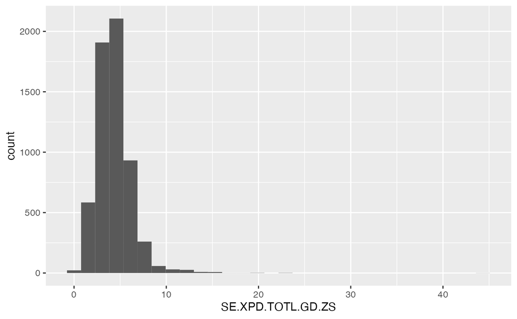

```r
wdi_ed_budget %>% ggplot(aes(x = SE.XPD.TOTL.GD.ZS)) + geom_histogram()
```

Added `drop_na(variable)` and changed `bins.`

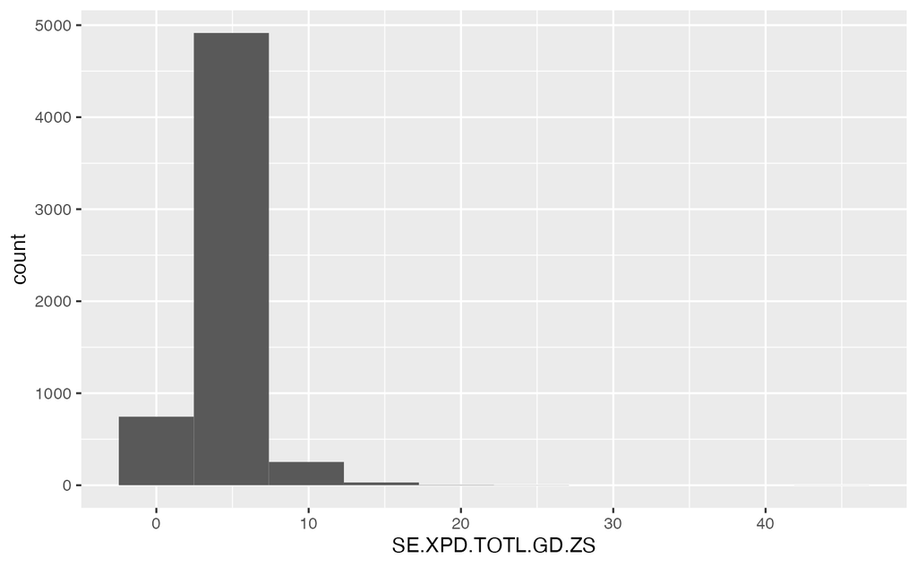

```r
wdi_ed_budget %>% drop_na(SE.XPD.TOTL.GD.ZS) %>%
  ggplot(aes(x = SE.XPD.TOTL.GD.ZS)) + geom_histogram(bins = 10)
```

We should see the variation using other visualization.

# Conclusions

Nothing is obtained yet!

Good luck.